# 140.651 - Lab 14

### HW6 Problem 2

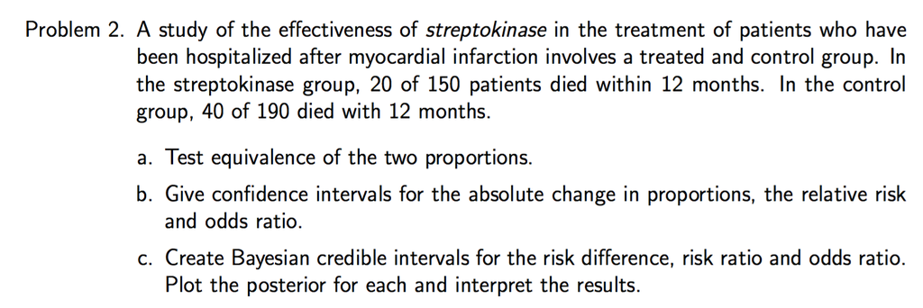

##### a. Test equivalence of the two proportions.

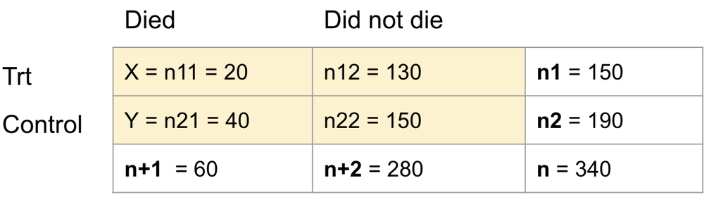

We specify null and alternative hypothesis:

$$\begin{aligned}
H_{0}: & p_{1}=p_{2}, \\
H_{1}: & p_{1} \neq p_{2}.
\end{aligned}$$

We can use z-test (score test) for comparing two proportions (Lecture 18, slides 11-12). The test statistic for this null hypothesis is

$$\begin{aligned}
T S=\frac{\hat{p}_{1}-\hat{p}_{2}}{\sqrt{\hat{p}(1-\hat{p})\left(\frac{1}{n_{1}}+\frac{1}{n_{2}}\right)}}
\end{aligned}$$

where $\hat{p}=\frac{n_{11}+n_{21}}{n_{1}+n_{2}}$ is estimate of the common proportion under the null hypothesis (sum of all cases to sum of all individuals).

```r
# ?prop.test
# x - a vector of counts of successes
# n - a vector of counts of trials
# correct - a logical indicating whether Yates' continuity correction should be applied
res <- prop.test(x = c(20, 40), n = c(150, 190), alternative = "two.sided", correct = FALSE)
res
```

```
##
##  2-sample test for equality of proportions without continuity
##  correction
##
## data:  c(20, 40) out of c(150, 190)
## X-squared = 3.4369, df = 1, p-value = 0.06375
## alternative hypothesis: two.sided
## 95 percent confidence interval:
##  -0.156689601  0.002303636
## sample estimates:
##    prop 1    prop 2
## 0.1333333 0.2105263
```

We got p-value of $0.06375$; we hence conclude that at significance level $\alpha=0.05$ we fail to reject the null hypothesis that the two proportions are equal.

##### b. Give confidence intervals for the absolute change in proportions, the relative risk and odds ratio.

##### (b1) Absolute change $p_1-p_2$

- Lecture 18 slide 14: Wald interval and test performs poorly relative to the score interval and test. For testing, always use the score test. For intervals, inverting the score test is hard and not offered in standard software. A simple fix is the Agresti/Caffo interval which is obtained by calculating

$$\begin{aligned}
\tilde{p}_{1} & =\frac{x+1}{n_{1}+2} \\
\tilde{p}_{2} & =\frac{y+1}{n_{2}+2} \\
\tilde{n}_{1} & =n_{1}+2 \\
\tilde{n}_{2} & =n_{2}+2.
\end{aligned}$$

- Adjusted estimates and sample size:

$$\begin{aligned}
\tilde{p}_1 & =\frac{x+1}{n_1+2}=\frac{20+1}{150+2} \\
\tilde{p}_2 & =\frac{y+1}{n_2+2}=\frac{40+1}{190+2}\\
\tilde{n}_1 & =n_1+2=152,\\
\tilde{n}_2 & =n_2+2=192.
\end{aligned}$$

- Use the adjusted values above to contruct Wald confidence interval:
  $$\tilde{p}_1-\tilde{p}_2\pm z_{1-\alpha/2}\sqrt{\frac{\tilde{p}_1(1-\tilde{p}_1)}{\tilde{n}_1}+\frac{\tilde{p}_2(1-\tilde{p}_2)}{\tilde{n}_2}}.$$

```r
p1td = (20+1)/(150+2)
p2td = (40+1)/(190+2)
n1td = 150+2
n2td = 190+2

p1td-p2td + c(-1,1)*qnorm(0.975)*sqrt(p1td*(1-p1td)/n1td+p2td*(1-p2td)/n2td)
```

```
## [1] -0.155191935  0.004424391
```

We observe that 95% confidence interval includes the value of difference specified in the null hypothesis, $p_1-p_2=0$. We hence we conclude that at significance level $\alpha=0.05$ we fail to reject the null hypothesis that the difference between the two proportions is different than 0.

##### (b2) Relative risk (RR)

From Lecture 19, slide 6:

The relative risk is defined as $p_1/p_2$. The natural estimator for the relative risk is

$$\begin{aligned}
\hat{R R}=\frac{\hat{p}_{1}}{\hat{p}_{2}}=\frac{X / n_{1}}{Y / n_{2}}
\end{aligned}$$

We follow Lecture 19, slides 8-9:

- We first find the CI of $\log(RR)$ and then exponentiate to get CI for RR.
- The standard error for $\log(\hat{p}_1/\hat{p}_2) = \log(\hat{p}_1) - \log(\hat{p}_2)$ is (lecture 19 slide 6)
  $$\Big(\frac{1-p_1}{p_1n_1}+\frac{1-p_2}{p_2n_2}\Big)^{1/2}$$
- This standard error formula can be derived using **multivariate delta method**. Suppose $\hat{p}$ is an estimator that satisfies$\frac{\hat{p}-p}{\hat{SE}_{\hat{p}}}\rightarrow_d N(0,1)$, $f(p)$ is a function of $p$.

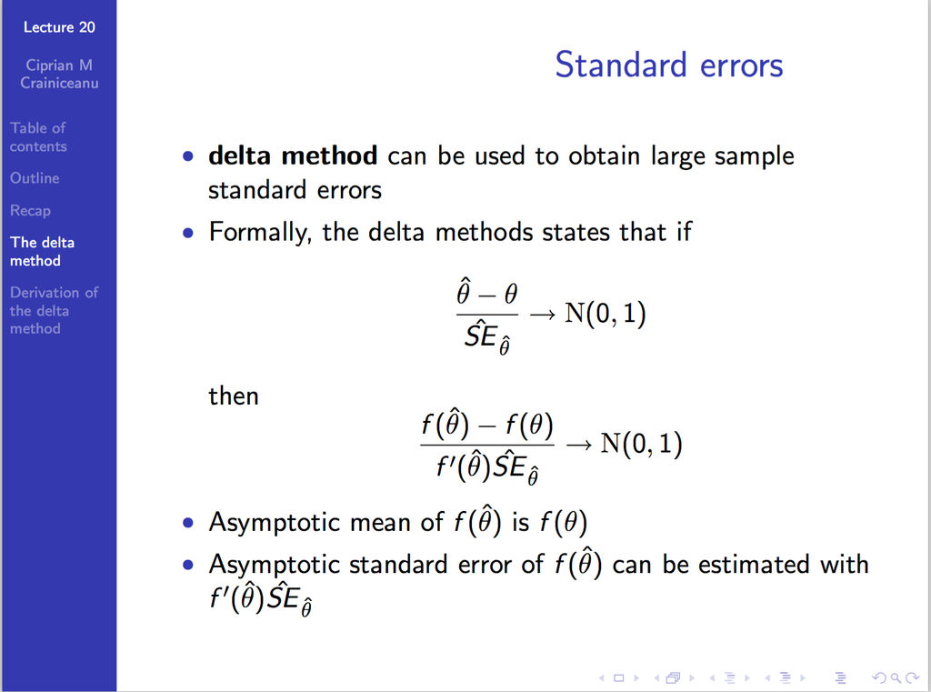

- Recall that for the univariate case, from the first order approximation of a Taylor series using Taylor’s theorem, we hae
  $$f(\hat{p})\approx f(p)+f'(p)(\hat{p}-p),$$
  hence we know
  $$var(f(\hat{p}))\approx f'(p)^2 \hat{SE}_{\hat{p}}^2\approx f'(\hat{p})^2\hat{SE}_{\hat{p}}^2.$$
- It is similar for multivariate case. Suppose $\hat{p}_1$ and $\hat{p}_2$ are estimates of risk for treatment and control group, respectively; further assume that they are independent; $f(p_1,p_2)$ is a function. By Taylor expansion
  $$f(\hat{p}_1,\hat{p}_2)\approx f(p_1,p_2)+\frac{\partial f}{\partial p_1}(p_1,p_2)(\hat{p}_1-p_1)+\frac{\partial f}{\partial p_2}(p_1,p_2)(\hat{p}_2-p_2),$$
  hence
  $$var(f(\hat{p}_1,\hat{p}_2))\approx \Big[\frac{\partial f}{\partial p_1}(p_1,p_2)\Big]^2 \hat{SE}_{\hat{p}_1}^2+\Big[\frac{\partial f}{\partial p_2}(p_1,p_2)\Big]^2 \hat{SE}_{\hat{p}_2}^2.$$
- For the log(relative risk) = $log(p_1/p_2)$,

$$\begin{aligned}
f(p_1,p_2) & =log(p_1/p_2) \\
\frac{\partial f}{\partial p_1}(p_1,p_2) & =1/p_1\\
\frac{\partial f}{\partial p_2}(p_1,p_2) & =-1/p_2\\
\hat{SE}_{\hat{p}_1}^2 & =p_1(1-p_1)/n_1\\
\hat{SE}_{p_2}^2 & =p_2(1-p_2)/n_2.
\end{aligned}$$

- Therefore

$$\var(\log(\hat{RR}))\approx\frac{1-p_1}{p_1n_1}+\frac{1-p_2}{p_2n_2}\approx \frac{1-\hat{p}_1}{\hat{p}_1n_1}+\frac{1-\hat{p}_2}{\hat{p}_2 n_2}=\frac{1-20/150}{20}+\frac{1-40/190}{40}\approx 0.063.$$

```r
SE_logRR = sqrt((1-20/150)/20 + (1-40/190)/40)
RR_CI = exp(log((20/150)/(40/190)) + c(-1,1)*qnorm(0.975)*SE_logRR)
RR_CI
```

```
## [1] 0.3871359 1.0360989
```

We observe that 95% confidence interval includes the value of relative risk specified in the null hypothesis, $p_1/p_2=1$. We hence we conclude that at significance level $\alpha=0.05$ we fail to reject the null hypothesis that the relative risk is different than 1.

##### (b3) Odds ratio (OR)

Similarly, we can use bivariate delta method to derive the SE for log(OR).

- Function and partial derivatives

$$\begin{align*}
f(p_1,p_2) &= log\Big(\frac{p_1/(1-p_1)}{p_2/(1-p_2)}\Big)\\
\frac{\partial f}{\partial p_1}(p_1,p_2)&=1/p_1+1/(1-p_1)=\frac{1}{p_1(1-p_1)}\\
\frac{\partial f}{\partial p_2}(p_1,p_2)&=-1/p_2-1/(1-p_2)=-\frac{1}{p_2(1-p_2)}
\end{align*}$$

- Therefore

$$\begin{align*}
var(log(\hat{OR}))&\approx\frac{1}{[p_1(1-p_1)]^2}\frac{p_1(1-p_1)}{n_1}+\frac{1}{[p_2(1-p_2)]^2}\frac{p_2(1-p_2)}{n_2}\\
&=\Big(\frac{1}{p_1}+\frac{1}{1-p_1}\Big)\frac{1}{n_1}+\Big(\frac{1}{p_2}+\frac{1}{1-p_2}\Big)\frac{1}{n_2}\\
&\approx \Big(\frac{1}{\hat{p}_1}+\frac{1}{1-\hat{p}_1}\Big)\frac{1}{n_1}+\Big(\frac{1}{\hat{p}_2}+\frac{1}{1-\hat{p}_2}\Big)\frac{1}{n_2}\\
&= \frac{1}{n_{11}}+\frac{1}{n_{12}}+\frac{1}{n_{21}}+\frac{1}{n_{22}}.
\end{align*}$$

```r
SE_logOR = sqrt(1/20+1/(150-20)+1/40+1/(190-40))
OR_CI = exp(log((20/130)/(40/150)) + c(-1,1)*qnorm(0.975)*SE_logOR)
OR_CI
```

```
## [1] 0.3211208 1.0364953
```

##### c. Create Bayesian credible intervals for the risk difference, risk ratio and odds ratio. Plot the posterior for each and interpret the results.

- Data model:
  $$X_1 \sim Binom(n_1, p_1) \\ X_2 \sim Binom(n_2, p_2)$$
- Priors:
  $$p_1\sim Beta(1,1), \\ p_2\sim Beta(1,1)$$
- Posteriors:
  $$p_1\mid X_1\sim Beta(X_1+1,n_1-X_1+1) \\ p_2\mid X_2\sim Beta(X_2+1,n_2-X_2+1)$$

Bayesian credible intervals can be easily computed via simulations.

```r
set.seed(123)
x1 = 20; n1 = 150
x2 = 40; n2 = 190
alpha1 = 1; beta1 = 1
alpha2 = 1; beta2 = 1

# simulate many values from posterior distributions of the two params
p1 = rbeta(1000, x1+alpha1, n1-x1+beta1)
p2 = rbeta(1000, x2+alpha2, n2-x2+beta2)
```

Generate credible intervals (“the equal-tailed” type; see more in [lab 11](https://courseplus.jhu.edu/fileDepot/onlineLibrary/516/2020_lab_11.html)):

```r
# Risk difference
rd = p1-p2
quantile(rd, c(0.025, 0.975))
```

```
##         2.5%        97.5%
## -0.156632819  0.003872778
```

```r
# Relative risk
rr = p1/p2
quantile(rr, c(0.025, 0.975))
```

```
##      2.5%     97.5%
## 0.3847186 1.0194550
```

```r
# Odds ratio
or = p1/(1-p1)/(p2/(1-p2))
quantile(or, c(0.025, 0.975))
```

```
##      2.5%     97.5%
## 0.3190116 1.0236650
```

### HW6 Problem 4

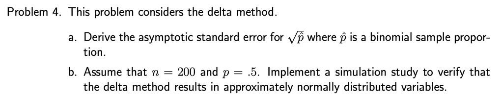

#### (a)

Denote:

- $X_1, X_2, \ldots, X_n$ - iid Bernoulli($p$) random variables,
- $\hat{p} = \bar{X}$ - estimator of true $p$.
- $var(X_i) = p(1-p)$

From CLT:

$$\begin{aligned}
\sqrt{n}(\hat{p}-p) \stackrel{D}{\rightarrow} N(0, p(1-p))
\end{aligned}$$

Let $f(x)=\sqrt{x}$. Then $f^{\prime}(x)=-\frac{1}{2 \sqrt{x}}$. By Delta Method,

$$\begin{aligned}
\sqrt{n}(\sqrt{\hat{p}}-\sqrt{p}) \stackrel{D}{\rightarrow}
N\left(0, p(1-p) \cdot \left( -\frac{1}{2 \sqrt{p}} \right)^2 \right) \\
\sqrt{n}(\sqrt{\hat{p}}-\sqrt{p}) \stackrel{D}{\rightarrow}
N\left(0, \frac{(1-p)}{4} \right) \\
(\sqrt{\hat{p}}-\sqrt{p}) \stackrel{D}{\rightarrow}
N\left(0, \frac{(1-p)}{4n} \right)
\end{aligned}$$

Hence the variance is $\frac{(1-p)}{4n}$, standard error is $\sqrt{\frac{(1-p)}{4n}}$ and we can approximate it by plugging $\hat{p} = \bar{X}$ - estimator of true $p$.

#### (b)

Our simulation is as follows:

1. Simulate 10,000 $Binom(n = 200, p = 0.5)$ random variables. Note $n=200$ in $Binom(n = 200, p = 0.5)$ denotes number of trials. That is, these random variables represent $10,000\times 200$ $Bernoulli(0.5)$ trials.
2. Calculate the estimated proportion $\hat{p}$ by dividing each $Binom(n = 200, p = 0.5)$ random variable observation by number of trails $200$.
3. Transform the data by taking the square root of $\hat{p}$.
4. Calculate empirical mean and variance of obtained $10,000$ values of $\sqrt{\hat{p}}$.
5. Using a qq-plot and looking at the density, observe if our simulation yields values of $\sqrt{\hat{p}}$ normally-distributed. If yes, compare the empirical mean and variance to those obtained by from the Delta method in part (a) to tell if the theoretical parameters of delta method-derived normal distribution are similar as empirical ones.

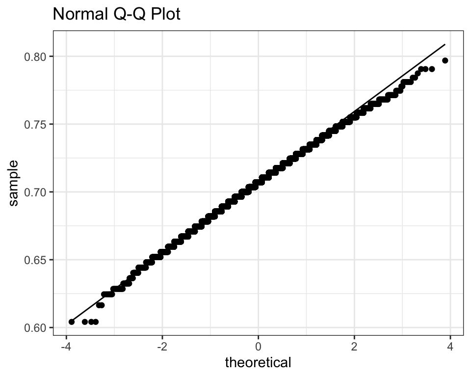

```r
library(ggplot2)
library(dplyr)
library(latex2exp)

set.seed(1)
binom <- rbinom(10000, 200, 0.5)  # Simulate 10000 binomial random variables
phat  <- binom/200                # Calculate proportions

# Check normality of the data
data.frame(sqrt_phat = sqrt(phat)) %>%
  ggplot(aes(sample = sqrt_phat)) +
  stat_qq() +
  stat_qq_line() +
  labs(title = "Normal Q-Q Plot") +
  theme_bw()
```

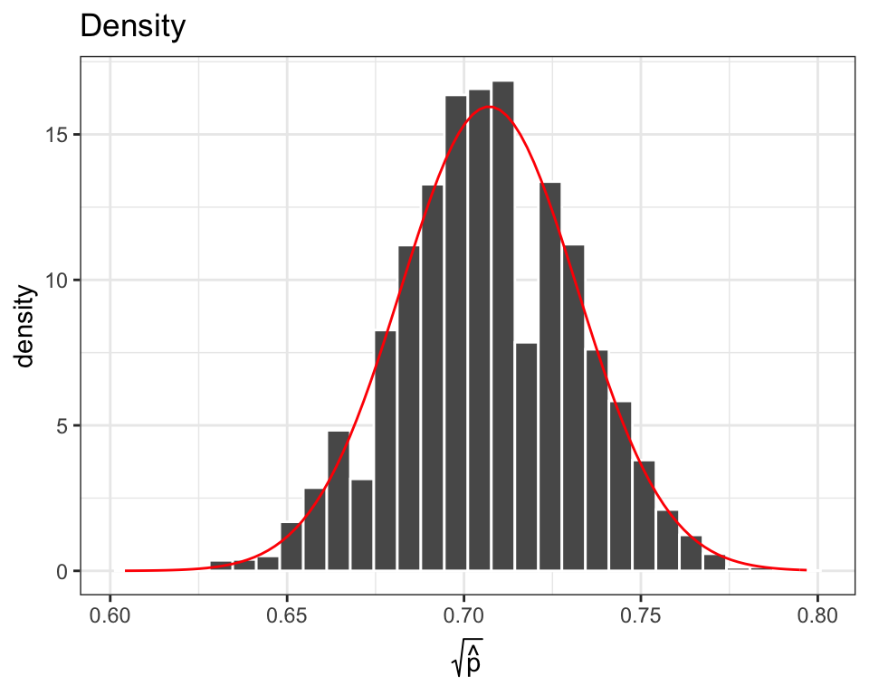

```r
# Look at density plot
data.frame(sqrt_phat = sqrt(phat)) %>%
  ggplot(aes(x = sqrt_phat)) +
  geom_histogram(aes(y = ..density..), bins = 30, color = 'white') +
  stat_function(color = 'red',
                fun = function(x)
                  dnorm(x, mean = sqrt(0.5), sd = sqrt((1-0.5)/(4*200)))) +
  labs(title = "Density", x = TeX('$\\sqrt{\\hat{p}}$')) +
  theme_bw()
```

```r
# Check if theoretical parameters of delta method-derived normal distribution
# are similar as empirical ones.
results <- data.frame(
  empirical = c(mean(sqrt(phat)), var(sqrt(phat))),
  delta = c(sqrt(0.5), (1-0.5)/(4*200)))
rownames(results) <- c("mean", "variance")
results
```

```
##             empirical     delta
## mean     0.7064737070 0.7071068
## variance 0.0006349648 0.0006250
```